# Assignment_assignment1_tasks

Yasuhiko Haga

2025-03-18

This file contains the code and the output from the assignment 1 Task 4-8

```r
library(ggplot2)
library(tidyverse)
```

##Task 4

```r
paste0("1. The square root of 10 is ", sqrt(10))
```

```
## [1] "1. The square root of 10 is 3.16227766016838"
```

```r
paste0("2. The logarithm of 32 to base 2 is ", log2(32))
```

```
## [1] "2. The logarithm of 32 to base 2 is 5"
```

```r
paste0("3. The sum of the numbers from 1 to 1000 is ", sum(seq(1000)))
```

```
## [1] "3. The sum of the numbers from 1 to 1000 is 500500"
```

```r
paste0("4. The sum of all even numbers from 2 to 1000 is ", sum(seq(2, 1000,2)))
```

```
## [1] "4. The sum of all even numbers from 2 to 1000 is 250500"
```

```r
paste0("5. The number of pariwise comparison for 100 genes is ", choose(100, 2))
```

```
## [1] "5. The number of pariwise comparison for 100 genes is 4950"
```

```r
paste0("6. The number of ways to arrange 100 genes in triples is ", length(combn(100, 3, simplify = F)))
```

```
## [1] "6. The number of ways to arrange 100 genes in triples is 161700"
```

##Task 5

```r
data(CO2)
help(CO2)
```

The output of help(CO2) printed the description shown partially below. Description The CO2 data frame has 84 rows and 5 columns of data from an experiment on the cold tolerance of the grass species *Echinochloa crus-galli*.

```r
mean_uptake_Quebec <- mean(CO2[CO2$Type == "Quebec", "uptake"])
mean_uptake_Mississippi <- mean(CO2[CO2$Type == "Mississippi", "uptake"])
median_uptake_Quebec <- median(CO2[CO2$Type == "Quebec", "uptake"])
median_uptake_Mississippi <- median(CO2[CO2$Type == "Mississippi", "uptake"])
knitr::kable(data.frame(Type = c("Quebec", "Mississippi"),
  mean_uptake = c(mean_uptake_Quebec, mean_uptake_Mississippi),
  median_uptake = c(median_uptake_Quebec, median_uptake_Mississippi)),
 caption = "Table of uptake by Type")
```

Table of uptake by Type

| Type | mean_uptake | median_uptake |
| --- | --- | --- |
| Quebec | 33.54286 | 37.15 |
| Mississippi | 20.88333 | 19.30 |

##Task 6

1. The function that calculate the ratio of the mean and the median of a given vector

```r
calc_ratio_of_mean_and_median <- function(x) {
  mean <- mean(x)
  median <- median(x)
  return(mean/median)
}
paste0("The ratio of the mean and the median of 0, 14, 37, 49, and 99 is ", calc_ratio_of_mean_and_median(c(0, 14, 37, 49, 99)))
```

```
## [1] "The ratio of the mean and the median of 0, 14, 37, 49, and 99 is 1.07567567567568"
```

2. The function that ignores the lowest and the highest value from a given vector and calculate the mean

```r
calc_mean_without_min_max <- function(x){
  if (length(x) < 3){
    return("can't calculate adjusted mean")
  }else{
    min <- min(x)
    max <- max(x)
    new_vec <- x[!x %in% c(min,max)]
    return(mean(new_vec))
  }
}

paste0("The ratio of the mean and the median of 0, 14, 37, 49, and 99 is ", calc_mean_without_min_max(c(0, 14, 37, 49, 99)))
```

```
## [1] "The ratio of the mean and the median of 0, 14, 37, 49, and 99 is 33.3333333333333"
```

3. Write a short explanation of why, how, and when not to use pipes. The pipe, %>%, is a powerful tool for writing a sequence of multiple operations. There are three situations should not use the pipe. First, the pipes are longer than ten steps, because it is not easy to debug codes. Second, there are multiple inputs or outputs. Finally, handling a directed graph with a complex dependency structures.
4. Write a short explanation of why the apply-family of functions (apply, lapply, sapply etc.) could useful in your work. Apply family functions can apply functions, like “mean” “median” “sum” etc., to a data object and return a data set. This helps us to minimize need to explicitly create loops, and make our codes look clear and easily understandable.

##Task 7

1

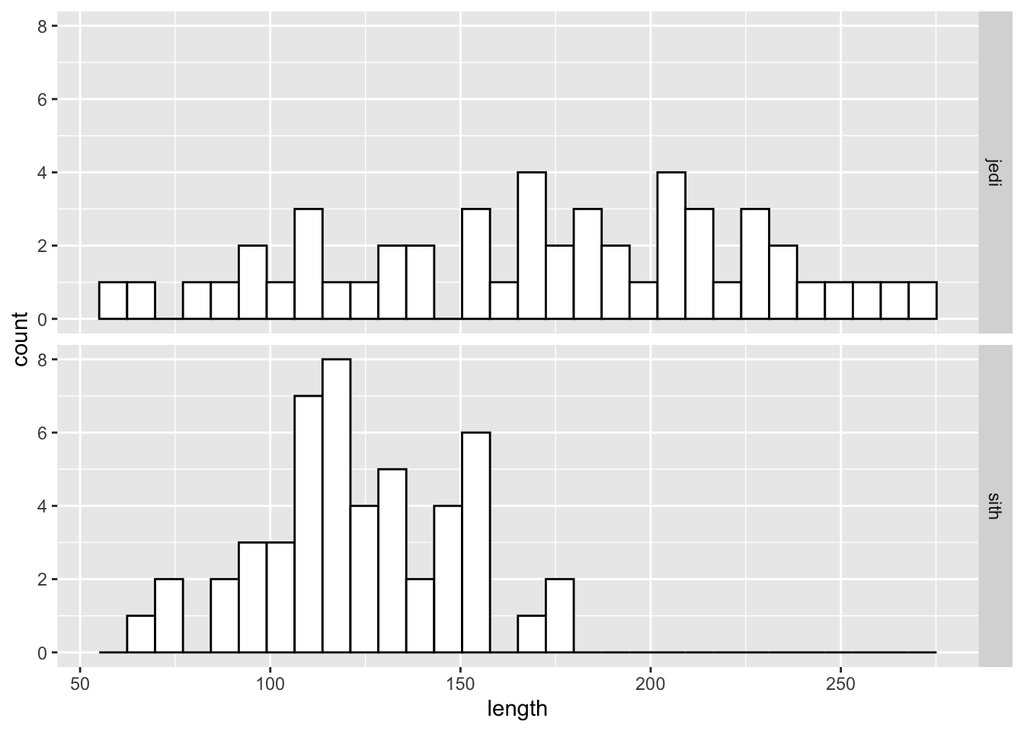

```r
#load magic_guys data
magic_guys <- read.csv(file = "./Week1-dataforTask7/magic_guys.csv", header = TRUE)

#1-a. hist
ggplot(magic_guys, aes(x = length)) + geom_histogram(fill = "white", colour = "black", bins = 30) + facet_grid(species ~ .)
```

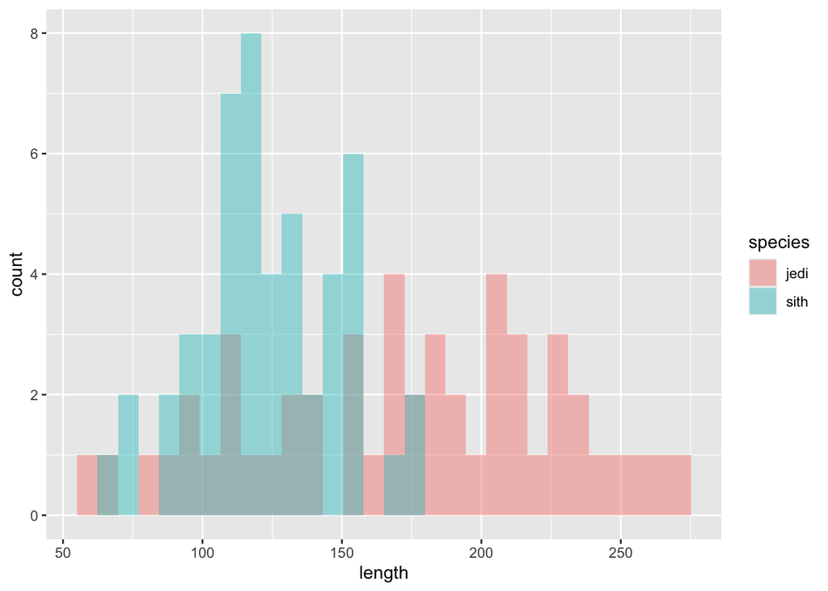

```r
ggplot(magic_guys, aes(x = length, fill = species)) + geom_histogram(position = "identity", alpha = 0.4, bins = 30)
```

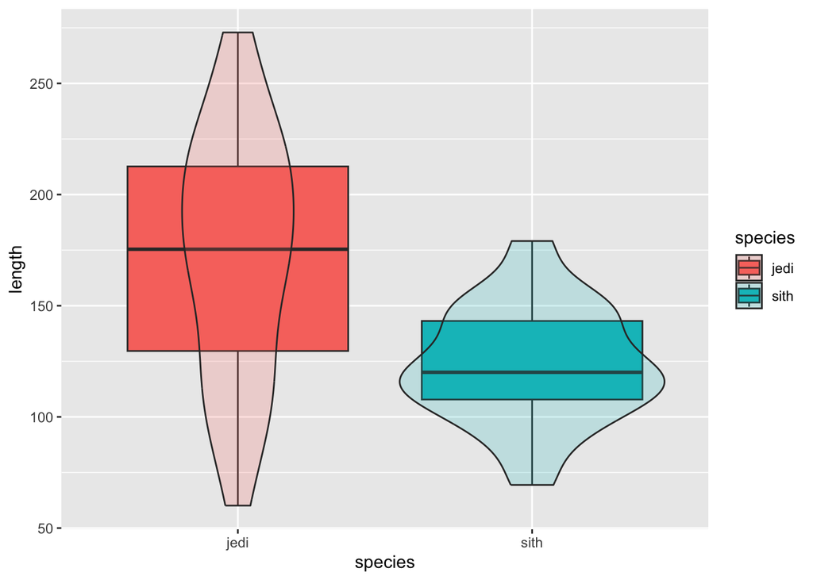

```r
#1-b. box
ggplot(magic_guys, aes(y = length, x = species, fill = species)) + geom_boxplot() + geom_violin(alpha=0.2)
```

1-c. How to save the plots *png png(“~/magic_guy_hist_overlapping.png”, width = 1024, height = 1024) ggplot(magic_guys, aes(x = length, fill = species)) + geom_histogram(position = “identity”, alpha = 0.4, bins = 30) dev.off()* pdf pdf(“~/magic_guy_hist_overlapping.pdf”, width = 4, height = 4) ggplot(magic_guys, aes(x = length)) + geom_histogram(fill = “white”, colour = “black”, bins = 30) + facet_grid(species ~ .) dev.off() *svg install.packages(“svglite”) library(svglite) ggsave(“~/magic_guy_hist_overlapping.svg”, width = 8, height = 8, units = “cm”)

PNG format usually has more data size than PDF format. But, when plotting point plots, PDF format often has more data size than PNG format. Because PDF format has information that is a mass of drawing order, and PNG format only has color information of bits. SVG format is better used for a web browser.

2

```r
#load magic_guys data
microarray <- read.table("./Week1-dataforTask7/microarray_data.tab", sep = "\t", header = TRUE)

#2-a
paste0("The number of rows is ", nrow(microarray), " and columns is ", ncol(microarray))
```

```
## [1] "The number of rows is 553 and columns is 1000"
```

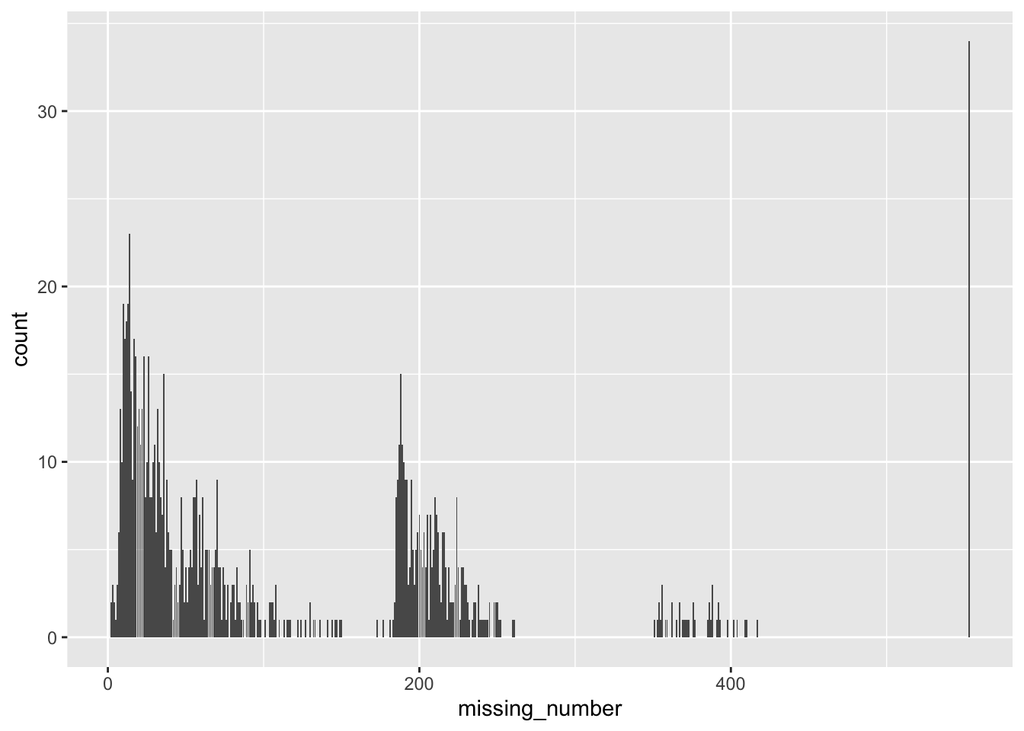

```r
#2-b
#row is gene
counted_missing_values <- matrix(data = NA, ncol = 2, nrow = ncol(microarray))
rownames(counted_missing_values) <- colnames(microarray)
colnames(counted_missing_values) <- c("missing_number", "expressed_gene_number")
#using for loop
for (i in colnames(microarray)) {
  counted_missing_values[i,1] <- sum(is.na(microarray[,i]))
  counted_missing_values[i,2] <- nrow(microarray) - sum(is.na(microarray[,i]))
}
ggplot(as.data.frame(counted_missing_values), aes(x = missing_number)) + geom_bar()
```

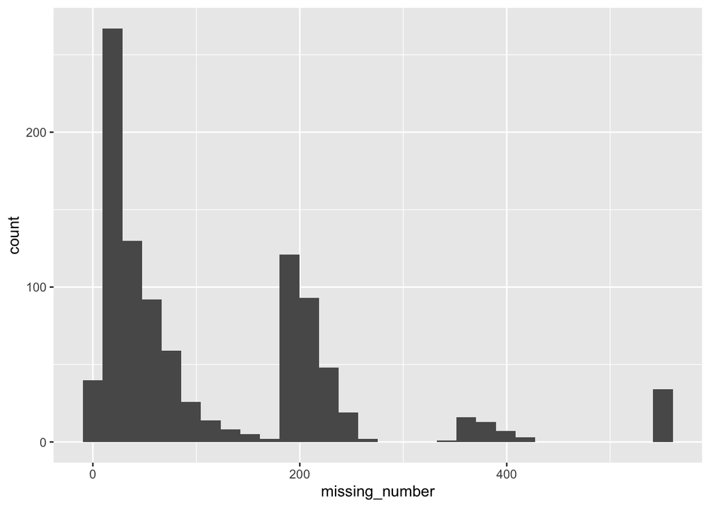

```r
ggplot(as.data.frame(counted_missing_values), aes(x = missing_number)) + geom_histogram()
```

```r
#2-c
#2-c
genes_miss_10per <- c()
genes_miss_20per <- c()
genes_miss_50per <- c()
for (i in rownames(counted_missing_values)) {
  missing_percent <- counted_missing_values[i,1] / (counted_missing_values[i,1] + counted_missing_values[i,2])
  if (missing_percent > 0.5) {
    genes_miss_50per[length(genes_miss_50per) + 1] <- i
  } else if (missing_percent > 0.2) {
    genes_miss_20per[length(genes_miss_20per) + 1] <- i
  } else if (missing_percent > 0.1) {
    genes_miss_10per[length(genes_miss_10per) + 1] <- i
  }
}

paste0("genes_miss_10per, genes_miss_20per, genes_miss_50per are the answer.")
```

```
## [1] "genes_miss_10per, genes_miss_20per, genes_miss_50per are the answer."
```

```r
#2-d
replaced_microarray <- microarray
for (i in colnames(microarray)) {
  mean_expression <- mean(microarray[,i], na.rm =TRUE)
  replaced_microarray[which(is.na(replaced_microarray[,i])),i] <- mean_expression
}
#replaced_microarray is the answer
```

3

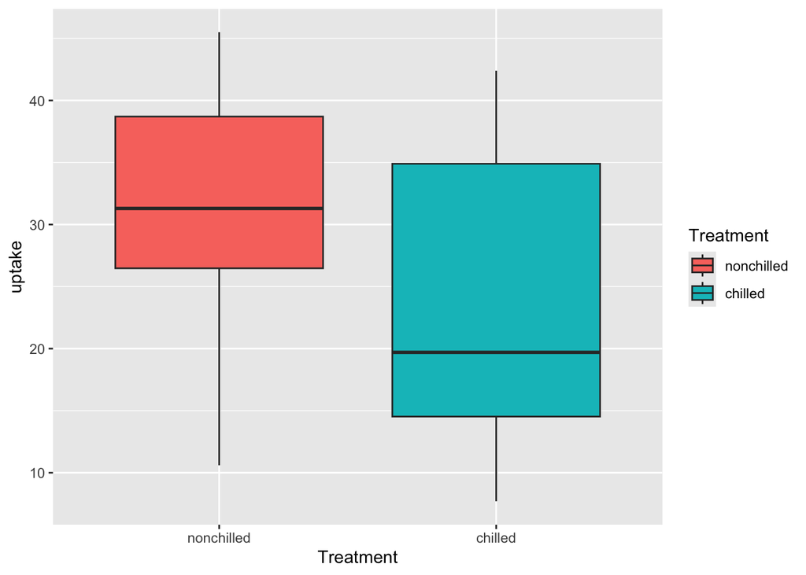

```r
#load CO2 data
data("CO2")
#compare uptake between Plants
ggplot(CO2, aes(x = Treatment, y = uptake, fill = Treatment)) + geom_boxplot()
```

```r
wilcox.test(x = CO2[CO2[,"Treatment"]=="nonchilled","uptake"], y = CO2[CO2[,"Treatment"]=="chilled","uptake"])
```

```
##
##  Wilcoxon rank sum test with continuity correction
##
## data:  CO2[CO2[, "Treatment"] == "nonchilled", "uptake"] and CO2[CO2[, "Treatment"] == "chilled", "uptake"]
## W = 1187.5, p-value = 0.006358
## alternative hypothesis: true location shift is not equal to 0
```

There is significant difference between nonchilled and chilled. (p_val = 0.006358, by wilcox.test) It is inferred that chilled treatment decrease plant’s CO2 uptake.